# Recommendation with Side Information

Encoding and fusing continuous, categorical, text, and image signals

Ben Dai

CUHK · Department of Statistics and Data Science

## The ID-only network is narrow

[figure not shown]

The ID-only graph has two inputs: a user ID and an item ID. Side information adds more inputs to the same graph.

## Modern recommenders have more signals

CONTINUOUS**price, age, time**

Numeric signals from profiles, content, or context.

CATEGORICAL**store, genre, device**

Discrete labels that can become embeddings.

TEXT**title, description**

Product or item text, encoded by an LLM or a smaller model.

IMAGE**photo, poster**

Product or item images, encoded by a CNN or ViT.

raw signal

*→*

encoder

*→*

vector

*→*

recommender

The modelling question is not “do we have IDs?” but “how do we encode and fuse all the information we have?”

## The dataset: Amazon Reviews 2023

A classroom subset of the **Video Games** category, built from the 5-core rating-only split. One row is one rating; product metadata joins on `item_id`.

**2,000**products

**39,796**ratings

**29,209**users

**300**product images

RATINGS**1–5 stars**

Continuous target; evaluate with RMSE.

PRODUCT METADATA**price + categories + text**

Price, store, category path, title, description, features.

SPLIT**random 80 / 20 rows**

Each rating is assigned to train or test at random; all users and items can appear in both.

Amazon Reviews 2023 (Hou et al., 2024). Rating-derived fields such as `average_rating` and `rating_number` are excluded; they would leak the target.

## How each modality enters the network

[figure not shown]

Each block has a different encoder, but the head sees vectors. That is the whole “load side information into the network” pattern.

## A concrete side-information table

| user | product | price | store | image | rating |
| --- | --- | --- | --- | --- | --- |
| AHNZ… | Pro Evolution Soccer 2013 | 20.25 | Konami | yes | 5 |
| AH5A… | Demon Slayer: Hinokami Chronicles | 34.98 | SEGA | yes | 4 |
| AFXA… | Sim Theme Park | 35.00 | Electronic Arts | no | 2 |
| AHJW… | Xbox One 1TB Console | 349.99 | Microsoft | no | 1 |

USER SIDE**history**

User ID and activity count from training interactions.

ITEM SIDE**metadata + text + image**

Title/description, price, store/category, product photo.

LABEL**rating 1–5**

A continuous star rating, evaluated with RMSE.

All four modalities are available before the rating. Exclude `average_rating` and `rating_number`: they leak the target.

## The whole lecture in one picture

1 · REQUIRED**Continuous**

Already a vector. Preprocess, then fuse.

2 · REQUIRED**Categorical**

Encode, then learn an embedding table.

3 · OPTIONAL**Text**

LLM encoder produces a dense vector.

4 · OPTIONAL**Image**

CNN or ViT produces a dense vector.

encode  
**raw feature → vector**

*→*

fuse  
**early concat or two towers**

*→*

evaluate  
**does it actually help?**

The encoder changes with the modality. The **fusion** and **evaluation** questions do not.

## Part 1 · Continuous features

Already vectors — preprocess, then fuse.

## Continuous features: price and user_count

$$x_{\text{cont}}=[\text{price}_z,\text{user count}_z]\in\mathbb R^2,\qquad g_{\text{cont}}(x)=\mathrm{Linear}_{16}(\mathrm{ReLU}(\mathrm{Linear}_2(x)))\in\mathbb R$$

| feature | raw | notebook transform | unseen / missing |
| --- | --- | --- | --- |
| `price` | 20.25 | `log1p` → train z-score | train median |
| `user_count` | 12 | training count → z-score | 0 |

NOTEBOOK BLOCK**2 → 16 → 1**

Section 2 prepares the columns; `MFNetCont` adds this block to `MFNet`. Scalers and counts use training rows only.

price + user_count  
**2 raw numbers**

*→*

log1p + z-score  
**training only**

*→*

concat  
**x<sub>cont</sub> ∈ ℝ²**

*→*

2 → 16 → 1  
**g<sub>cont</sub>(x)**

`X["cont"]` has exactly these two columns. Other product metadata belongs to the categorical, text, or image block.

## Three ways to fuse continuous features

[figure not shown]

**Early concat** lets one MLP learn all interactions; **additive MF** keeps the ID score and adds a feature correction; **two towers** encode each side separately before the dot product.

## Part 2 · Categorical features

A category is an ID. An embedding is a learned lookup table.

## A category is an ID

[figure not shown]

User ID, store, category — the same `nn.Embedding` lookup; only the table size changes.

## Continuous + categorical fusion

[figure not shown]

The recommender only sees vectors. Swapping an encoder should not change the fusion block.

## Part 3 · Fusion architectures

Same encoders, different interaction.

## Three ways to use side information

FEATURES ONLY**$f(x_u,z_i)$**

Handles new IDs, but may miss individual preferences.

ADD TO MF**$p_u^\top q_i+f(x_u,z_i)$**

Keeps personalized ID factors and adds a feature contribution.

SIDE-AWARE FACTORS**$p(u,x_u)^\top q(i,z_i)$**

Builds each factor from ID and features together.

Use features-only when IDs are weak; additive MF when IDs are strong; side-aware factors when both sides have rich features.

The third approach makes the interaction depend on the features on **both** sides.

## Feature-only vs additive MF

$$\begin{aligned}
\text{feature-only:}\quad & \widehat r_{ui}=f_\theta(x_u,z_i)\\
\text{additive MF:}\quad & \widehat r_{ui}=\mu+a_u+b_i+p_u^\top q_i+f_\theta(x_u,z_i)
\end{aligned}$$

[figure not shown]

**Feature-only** works for a new ID but has no individual preference. **Additive MF** keeps the ID score and adds a feature correction — the safest first model.

## Side-aware factors

$$\begin{aligned}
p(u,x_u)&=p_u+A x_u+e_{c(u)}\\
q(i,z_i)&=q_i+B z_i+e_{g(i)}\\
\widehat r_{ui}&=p(u,x_u)^\top q(i,z_i)
\end{aligned}$$

[figure not shown]

Features and category embeddings build each factor; the ID term is a learned residual. A new ID sets the residual to zero, but the feature path still produces a vector.

## Two-tower architecture

[figure not shown]

Each tower learns nonlinear interactions **within** its side; the final layer learns the interaction **across** sides.

## Part 4 · Train, evaluate, diagnose

The model is only as good as the split.

## Four questions and the loss

1 · MODEL**ID score + one block per modality**

Start with `MFNet`; add only the blocks the data supports.

2 · HYPERPARAMETERS**$K$, hidden, learning rate, epochs**

Choose before fitting; tune on validation.

3 · CRITERION**mean squared error**

MSE on the observed 1–5 ratings.

4 · LEARNED**tables + blocks**

ID/category embeddings, biases, and the additive blocks.

$$\mathrm{L}(\theta)=\frac1{|\Omega|}\sum_{(u,i)\in\Omega}(r_{ui}-\widehat r_{ui})^2$$

One MSE trains the ID tables and every side-information block. Select hyperparameters on validation.

## One dict, one named input per modality

$$X=\{\mathrm{ids}:(N,2),\ \mathrm{cont}:(N,2),\ \mathrm{cat}:(N,3),\ \mathrm{text}:(N,384),\ \mathrm{image}:(N,512)\}$$

`X["ids"]`  
**user, item**

*→*

`forward(ids, …)`  
**named argument**

*→*

`MFNet`  
**base score**

WHY A DICT**one key per modality**

A new block adds a key; it does not move column positions.

SKORCH**keys become arguments**

`X["cont"]` is passed to `forward(…, cont)`.

MODEL**take only what you need**

`MFNet` uses `ids`; `MFNetText` also uses `text`.

A new modality is a new dictionary key and a new named argument — not a new column index.

## A PyTorch implementation sketch

```python
class MFNetCont(MFNet):
    def __init__(self, n_users, n_items, K=16, mu=0.0, d_cont=2):
        super().__init__(n_users, n_items, K, mu)
        self.cont = nn.Sequential(
            nn.Linear(d_cont, 16), nn.ReLU(), nn.Linear(16, 1)
        )

    def forward(self, ids, cont):
        return super().forward(ids) + self.cont(cont)
```

For this model, `X` only needs `ids` and `cont`; later models receive larger dicts.

One subclass, one new block. The dict keys select the named arguments; `skorch` handles the training loop and prediction.

## A random row split

SPLIT**80 / 20 random rows**

31,836 train rows · 7,960 test rows. No user or item is deliberately removed.

WHAT IT MEASURES**interpolation**

IDs are not held out; most test rows reuse users and items seen in training.

WHAT IT DOES NOT**new-item generalization**

A random split does not test a genuinely new product or a new user.

SAFE**fit preprocessing on training rows**

Scalers and rating summaries use training rows only; ID vocabularies can use the catalogue.

LEAKY**rating-derived features**

Rating mean, rating count, or quantile computed from the target leaks even in a random split.

The notebook uses a random 80/20 split, so report test RMSE and describe it as in-distribution interpolation.

## Baselines and ablation

Random 80/20 row split: 31,836 train rows · 7,960 test rows. Select on validation; report test once. Lower RMSE is better.

| model | added input | validation RMSE | test RMSE |
| --- | --- | --- | --- |
| MFNet | IDs only | 1.1644 | 1.1587 |
| + continuous | price + user_count | 1.1656 | 1.1589 |
| + categorical | store + category path | 1.1635 | 1.1598 |
| + text | MiniLM title + description | **1.1589** | **1.1535** |

Image subset (300 products): text only **1.1437** → + image **1.1438**. Not comparable with the full table.

CLEAR GAIN**+ text**

0.0052 lower test RMSE than MFNet.

NO RELIABLE GAIN**+ continuous / categorical**

Changes are tiny and do not hold on test.

NEUTRAL**+ image**

+0.0001 on the image subset.

More side information is not automatically better. On this split, text is the only clear gain; the image block is neutral.

Intuition: with a random split the item ID is already seen in training, so price and category add little beyond the ID; text still adds product semantics.

## Part 5 · Text side information

Optional Product text → embedding → a small additive block.

## Text: what goes in

| field | example | why |
| --- | --- | --- |
| `title` | Pro Evolution Soccer 2013 | short, high signal |
| `description` | long product copy | use cases and context |
| `features` | bullet list | structured attributes |

$$\text{text}_i=\text{title}_i\;\|\;\text{description}_i\;\|\;\text{features}_i$$

One string per `item_id`: 2,000 products, one embedding each.

USE**product text**

Title, description, and feature bullets are available before the rating.

DO NOT USE**review text**

Review title/text is written together with the star rating; it leaks the target.

One string per product, built from product metadata only. Review text is not a feature.

## Text: the feature-extraction pipeline

```python
# Colab: !pip -q install transformers
import numpy as np
from transformers import pipeline

embed = pipeline("feature-extraction", model="sentence-transformers/all-MiniLM-L6-v2")
texts = (items.title.fillna("") + " " +
         items.description.fillna("") + " " +
         items.features.fillna("")).tolist()
out = embed(texts, batch_size=64,
            truncation=True, max_length=256)
# out[i][0].shape -> (n_tokens, 384)
text_vectors = np.array([np.mean(o[0], axis=0) for o in out])  # (n_items, 384)
```

one string  
**title + description + features**

*→*

tokenizer  
**truncate at 256**

*→*

MiniLM  
**(n_tokens, 384)**

*→*

mean pool  
**(384,)**

`feature-extraction` returns one vector per token, not one vector per product. Mean pooling turns it into a single 384-d embedding.

## Text: append the vector and add a block

$$\begin{aligned}
\widehat r_{ui}&=\text{MFNet}(u,i)+g_{\text{cont}}+g_{\text{cat}}+g_{\text{text}}(e_i)\\
g_{\text{text}}(e)&=\mathrm{Linear}_{16}(\mathrm{ReLU}(\mathrm{Linear}_{32}(e)))\in\mathbb R
\end{aligned}$$

New input: `X["text"] = e_text`, shape `(N, 384)`. `MFNetText.forward(ids, cont, cat, text)`.

text embedding  
**e<sub>i</sub> ∈ ℝ<sup>384</sup>**

*→*

projection  
**384 → 32**

*→*

text block  
**32 → 16 → 1**

*→*

additive correction  
**+ g<sub>text</sub>(e<sub>i</sub>)**

Trainable parameters: 12,320 + 528 + 17 ≈ 12.9k; MiniLM stays frozen at ~22M.

This is `MFNetText`: one projection, one small block, added to the existing score. The MiniLM encoder stays frozen.

## Text: frozen, fine-tuned, or fused

FROZEN**start here**

Precompute 2,000 × 384; train only the projection and block. Cheap and reproducible.

FINE-TUNED**only with evidence**

Update MiniLM only when the domain is specialized and frozen features clearly underperform.

FUSED**project first**

Project 384 → 32, then add or concat. L2-normalize if using cosine-style retrieval.

BATCH**64**

Embed in batches; cache the matrix.

LENGTH**256 tokens**

Truncate long descriptions.

JOIN**item_id**

One embedding per product; map to rating rows.

COST**one pass**

No encoder call at serving time.

Freeze first, cache the 2,000 embeddings, and measure on the same random split. Fine-tune only with evidence.

## Part 6 · Image side information

Optional Product photo → 512-d vector → a small additive block.

## Image: what goes in

[figure not shown]

One of the 300 product photos in the subset.

SOURCE**image_path**

Prefix with the local dataset folder; in Colab, prefix with the GitHub `BASE` URL.

SUBSET**300 products**

One embedding per product; the image ablation uses only rating rows for these products.

LEAKAGE**available before the rating**

The product photo is metadata, not review content. Do not use review images or rating-derived fields.

Only a subset has an image, so image results are not directly comparable with the full-table numbers.

## Image: the feature-extraction pipeline

```python
from transformers import pipeline

embed_image = pipeline(
    "image-feature-extraction",
    model="microsoft/resnet-18",
)

image_items = items[items.image_path.notna()]
paths = [f"{LOCAL or BASE}/{p}" for p in image_items.image_path]

image_vectors = np.array(
    embed_image(paths, batch_size=32, pool=True)
).reshape(len(paths), -1)
image_vectors /= np.linalg.norm(image_vectors, axis=1, keepdims=True)
image_emb = pd.DataFrame(image_vectors, index=image_items.item_id)
d_image = image_emb.shape[1]   # 512
```

image path / URL  
**300 products**

*→*

ResNet18  
**frozen backbone**

*→*

feature map  
**(1, 512, 1, 1)**

*→*

flatten  
**(512,)**

`pool=True` averages the 7×7 feature map; each vector is then L2-normalized.

`image-feature-extraction` returns a spatial tensor; flatten it to one 512-d vector per product.

## Image: append the vector and add a block

$$\begin{aligned}
\widehat r_{ui}&=\text{MFNet}(u,i)+g_{\text{cont}}+g_{\text{cat}}+g_{\text{text}}(e_i)+g_{\text{image}}(v_i)\\
g_{\text{image}}(v)&=\mathrm{Linear}_{16}(\mathrm{ReLU}(\mathrm{Linear}_{32}(v)))\in\mathbb R
\end{aligned}$$

New input: `X["image"] = v_i`, shape `(N, 512)`. `MFNetImage.forward(ids, cont, cat, text, image)`.

image embedding  
**v<sub>i</sub> ∈ ℝ<sup>512</sup>**

*→*

projection  
**512 → 32**

*→*

image block  
**32 → 16 → 1**

*→*

additive correction  
**+ g<sub>image</sub>(v<sub>i</sub>)**

Trainable: 16,416 + 528 + 17 ≈ 17k; ResNet18 stays frozen. Evaluate on the 300-image subset.

`MFNetImage` inherits `MFNetText` and adds one projection plus one block.

## Image: frozen, fine-tuned, or multimodal

FROZEN**start here**

Precompute 300 × 512; train only the projection and image block.

FINE-TUNED**domain shift**

Fine-tune the last block only when you have enough images and compute.

MULTIMODAL**early or late**

Concat for ranking; image tower for retrieval; CLIP-style alignment for zero-shot items.

INPUT**300 images**

Paths or URLs; batch 32.

FEATURE**512-d unit vector**

Flatten the pooled ResNet map; L2-normalize.

BLOCK**512 → 32**

then 16 → 1; small additive head.

COST**one pass**

Cache embeddings; no CNN at serving time.

Image subset: text only **1.1437** → + image **1.1438**. No gain; freeze first and measure.

## Part 7 · Industry systems

Optional Same pattern at scale.

## YouTube: two-tower retrieval

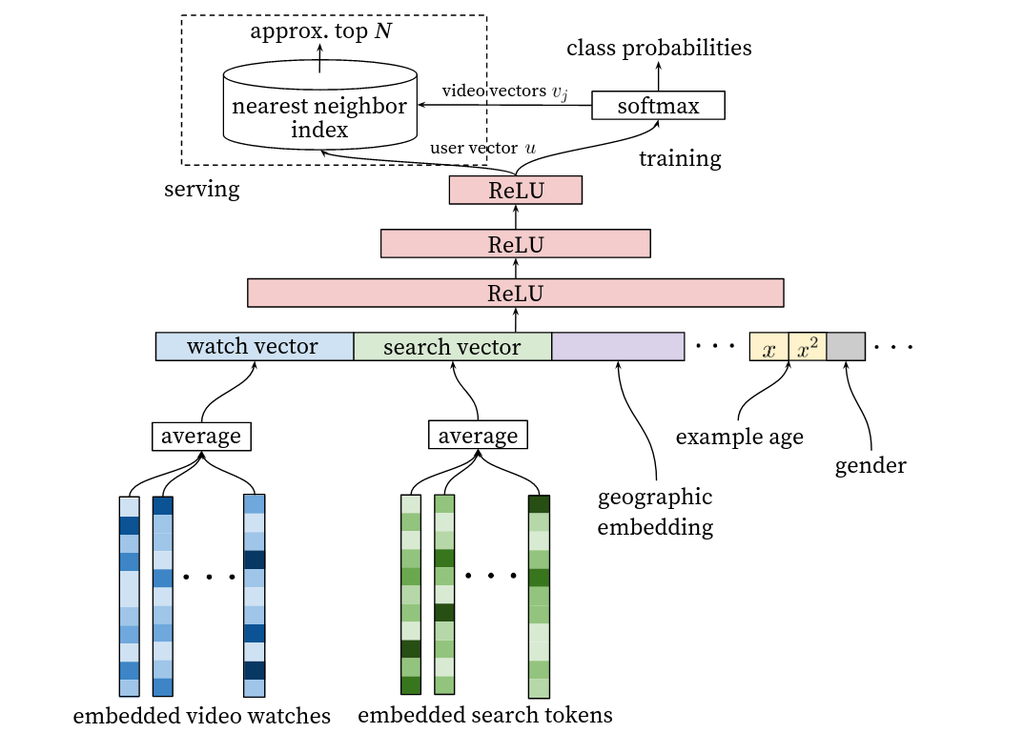

USER TOWER**watch + search + context**

Average embeddings, then ReLU layers produce the user vector *u*.

ITEM TOWER**video vectors**

Softmax trains the item side; nearest-neighbour search serves candidates.

SIDE INFO**history is a feature**

Watch/search sequences and demographics enter before the final interaction.

The two-tower pattern is a retrieval architecture first; the same encoders can feed a ranking model later.

## eBay: sequence plus content

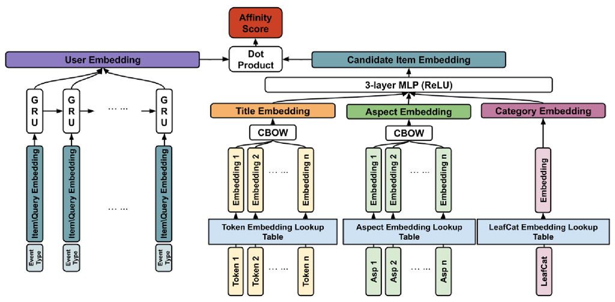

USER TOWER**event sequence → GRU**

Clicks and purchases become a user embedding.

ITEM TOWER**text + category → MLP**

Title and aspect CBOW embeddings plus a leaf-category embedding.

SCORE**dot product**

Affinity between the user and candidate item embedding.

Same two-tower pattern: a sequence encoder on the user side, a text/category encoder on the item side.

## Alibaba: behavior sequence + feature crossing

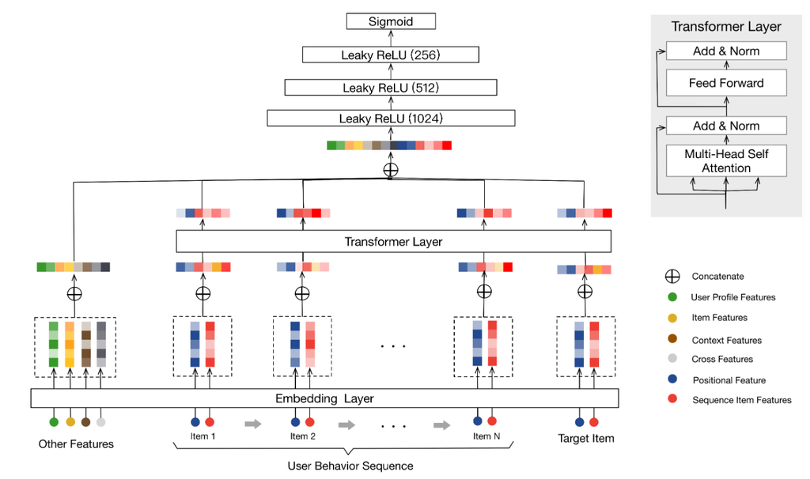

INPUT**profile + item + context**

Other features and the user behavior sequence enter the embedding layer.

SEQUENCE**Transformer**

Multi-head self-attention models the order of past items.

OUTPUT**click probability**

Concatenate target item with sequence output; MLP + sigmoid.

Alibaba uses a sequence Transformer plus feature crossing; Wide & Deep and DeepFM are earlier early-fusion variants.

## Retrieval vs ranking, and the feature store

|  | retrieval | ranking |
| --- | --- | --- |
| goal | millions → hundreds | hundreds → top few |
| model | two-tower, dot product | richer MLP, crosses, context |
| latency | milliseconds | tens of milliseconds |
| features | available for every candidate | rich user/item/context features |

FEATURE STORE**offline / online**

The same feature definition must be available at training and serving time.

FRESHNESS**time matters**

A rating mean computed yesterday is not the same feature today.

A side-information model is also a data-engineering contract. Training-serving skew is a modelling bug.

## Summary

ID-only MF  
**personalization**

*→*

continuous + categorical  
**tabular side info**

*→*

text + image  
**optional encoders**

*→*

two-tower  
**learned fusion**

*→*

random split  
**honest evaluation**

ENCODE**modality → vector**

Scale, embed, or pretrain; the recommender sees vectors.

FUSE**early or late**

Additive maps for interpretability; two towers for new entities and retrieval.

EVALUATE**match the claim**

Random split: report test RMSE. Add new-entity splits only for generalization claims.

Side information is a representation strategy, a fusion choice, and an evaluation protocol — and on this dataset, only text improved test RMSE.

## References

- Covington, Adams & Sargin (2016). *Deep Neural Networks for YouTube Recommendations*.
- Wang, Brovman & Madhvanath (2021). *Personalized Embedding-based E-commerce Recommendations at eBay*.
- Hou et al. (2024). *Bridging Language and Items for Retrieval and Recommendation* (Amazon Reviews 2023).
- Chen et al. (2019). *Behavior Sequence Transformer for E-commerce Recommendation in Alibaba*.
- Cheng et al. (2016). *Wide & Deep Learning for Recommender Systems*; Guo et al. (2017). *DeepFM*.
- PyTorch `nn.Embedding`; scikit-learn `OneHotEncoder`, `StandardScaler`; Hugging Face `pipeline(“feature-extraction”)` and `pipeline(“image-feature-extraction”)`; Sentence Transformers `all-MiniLM-L6-v2`; `microsoft/resnet-18`; CLIP.